# Tutorial 3 — Model Validation

Hurricane Wind Hazard Model for the Caribbean

Published

March 16, 2026

**Prerequisites**

This tutorial assumes you have already completed Tutorial 1 and Tutorial 2. Those tutorials introduce the baseline model workflow and the main `out` object that we validate here.

This tutorial shows how to check whether the hazard model is behaving credibly before you use it for interpretation or decision support. We will recreate a stationary baseline run with the demo dataset, configure the validation suite, inspect each validation tier, and review the saved plots and tables.

## 1 What This Tutorial Covers

By the end, you will be able to:

- create a standalone model output suitable for validation
- run the full validation suite with `make_validation_cfg()` and `run_validation_suite()`
- interpret the three validation tiers and the saved diagnostics they produce

## 2 Overview

The validation workflow has four steps:

1. Run the hazard model for a few target islands.
2. Create a validation configuration that defines the holdout period, simulation size, confidence level, and output directory.
3. Run the validation suite and inspect the top-level summary.
4. Review the three validation tiers: hindcast return levels, rate sanity, and wind field spot-checks.

```r
library(ipdcstorm)
library(dplyr)
library(ggplot2)
```

## 3 Create a Model Output to Validate

Before validating, we need a model output to check. This tutorial recreates a small stationary baseline run so it renders on its own from a clean session.

```r
seed <- 123L
simulation_years <- 500L

ibtracs_demo <- system.file(
  "extdata",
  "ibtracs_demo.csv",
  package = "ipdcstorm"
)

targets <- data.frame(
  name = c("St_Martin", "Saba", "Statia"),
  lat = c(18.0708, 17.6350, 17.4890),
  lon = c(-63.0501, -63.2300, -62.9740)
)

cfg <- make_hazard_cfg(
  data_path = ibtracs_demo,
  historical_start_year = 1970L,
  search_radius_km = 800,
  simulation_years = simulation_years,
  climate = make_climate_cfg(scenario = "stationary")
)
```

```r
out <- run_hazard_model(
  cfg = cfg,
  targets = targets,
  seed = seed,
  verbose = FALSE
)
```

The object `out` is the same kind of model output you would usually carry forward from your own baseline workflow. Here we reuse the bundled demo data so the tutorial is fully self-contained.

## 4 Why Validate?

The hazard model combines several ingredients: a parametric wind profile, site-level event classification, annual rate estimation, and stochastic resampling of historical storms. Each of those choices can introduce bias, even when the code runs without error.

The validation suite checks three different aspects of performance: return levels, storm rates, and wind field accuracy. A model can pass one tier and fail another, so looking at all three tiers together is more informative than relying on a single score.

## 5 Validation Configuration

We control the validation workflow with `make_validation_cfg()`. This keeps the main choices in one place: how long the holdout period is, how many synthetic years to generate for the hindcast, which return periods to compare, and where to save outputs.

```r
val_cfg <- make_validation_cfg(
  holdout_years = 10L,
  n_sim = 2000L,
  return_periods = c(5, 10, 25, 50),
  conf_level = 0.90,
  seed = 123L,
  out_dir = "output/validation",
  save_plots = TRUE,
  save_tables = TRUE
)

val_cfg
```

```
#> Validation configuration
#>   Holdout       : 10 years
#>   Simulation    : 2,000 synthetic years
#>   Return periods: 5, 10, 25, 50 yr
#>   Conf. level   : 90%
#>   Seed          : 123
#>   Output dir    : output/validation
#>   Save plots    : yes
#>   Save tables   : yes
#>   GEV xi bounds : [-0.30, 0.40]
```

| Parameter | Description |
| --- | --- |
| `holdout_years` | Number of years held out from the end of the historical record for the train/test split. |
| `n_sim` | Number of synthetic years simulated for the hindcast comparison. If `NULL`, this inherits from the hazard model output. |
| `return_periods` | Return periods (years) to compare between observed and simulated annual maxima. |
| `conf_level` | Confidence level for return-level CIs. This controls how strict the pass/fail test is. |
| `seed` | Random seed for reproducibility. |
| `out_dir` | Directory where plots and CSV tables are saved. |
| `save_plots` | Whether to save PNG diagnostic figures. |
| `save_tables` | Whether to save CSV result tables. |

## 6 Run the Validation Suite

With the hazard run complete and the validation settings defined, we can run the full suite in one call. The function prints a formatted console summary while it runs and returns all tier results in one structured object.

```r
val <- run_validation_suite(
  out = out,
  cfg = val_cfg
)
```

```r
val$summary
```

```
#> # A tibble: 3 × 4
#>   location  storm_class delta_top1_p50 delta_overall_p99
#>   <chr>     <chr>                <dbl>             <dbl>
#> 1 Saba      TS                   -16.0             -6.85
#> 2 St_Martin TS                   -31.3            -13.0
#> 3 Statia    TS                   -27.6            -14.1
```

```r
# The current runtime may not always register the rate plot path in val$artifacts.
# Populate the expected saved path so the tutorial can display every plot inline.
if (is.null(val$artifacts$plots$rate_comparison)) {
  rate_plot_path <- file.path(val_cfg$out_dir, "rate_comparison.png")
  if (!file.exists(rate_plot_path)) {
    plot_rate_validation(val, cfg = val_cfg)
  }
  if (file.exists(rate_plot_path)) {
    val$artifacts$plots$rate_comparison <- rate_plot_path
  }
}
```

**Saved results**

The `val` object contains all validation results in memory, and the plots and CSV tables have been saved to `output/validation/`. That makes it easy to inspect the objects interactively and also keep a reproducible set of artifacts on disk.

## 7 Tier 1 — Hindcast Return Levels

Tier 1 asks a simple question: if we train the model on the earlier part of the record, does it reproduce the return levels implied by the full observed record? The suite holds out the last `holdout_years`, fits the model on the earlier years, simulates synthetic annual maxima, and then compares return levels across several return periods.

The main pass/fail idea is straightforward: the simulated return level should fall inside the confidence interval around the observed return-level estimate. That gives us a check on whether the model is broadly reproducing the upper tail of the observed site-wind distribution.

```r
val$hindcast$comparison
```

```
#> # A tibble: 12 × 15
#>    location  return_period obs_full_rl obs_test_rl sim_rl sim_median sim_ci_lo
#>    <chr>             <dbl>       <dbl>       <dbl>  <dbl>      <dbl>     <dbl>
#>  1 Saba                  5        50.2        46.6   55.7       55.7        NA
#>  2 Saba                 10        60.4       125.    67.3       67.3        NA
#>  3 Saba                 25        69.1       142.    78.5       78.5        NA
#>  4 Saba                 50        74.0       142.    85.6       85.6        NA
#>  5 St_Martin             5        51.3        65.2   54.0       54.0        NA
#>  6 St_Martin            10        61.2       136.    64.6       64.6        NA
#>  7 St_Martin            25        69.8       150.    74.9       74.9        NA
#>  8 St_Martin            50        74.6       150.    81.2       81.2        NA
#>  9 Statia                5        49.2        48.1   54.7       54.7        NA
#> 10 Statia               10        58.1       116.    66.2       66.2        NA
#> 11 Statia               25        65.8       131.    79.1       79.1        NA
#> 12 Statia               50        70.0       131.    88.2       88.2        NA
#> # ℹ 8 more variables: sim_ci_hi <dbl>, obs_ci_lo <dbl>, obs_ci_hi <dbl>,
#> #   obs_ci_method <chr>, obs_in_ci <lgl>, model_in_obs_ci <lgl>,
#> #   obs_in_model_ci <lgl>, bias_pct <dbl>
```

| Column | Description |
| --- | --- |
| `location` | Target island. |
| `return_period` | Return period in years. |
| `obs_full_rl` | Observed return level from the full historical record (kt). |
| `sim_rl` | Simulated return level from the hindcast experiment (kt). |
| `obs_ci_lo` | Lower confidence bound for the observed return level. |
| `obs_ci_hi` | Upper confidence bound for the observed return level. |
| `obs_in_ci` | Whether the simulated estimate falls within the observed CI. |
| `bias_pct` | Percentage bias, with positive values meaning model overprediction. |

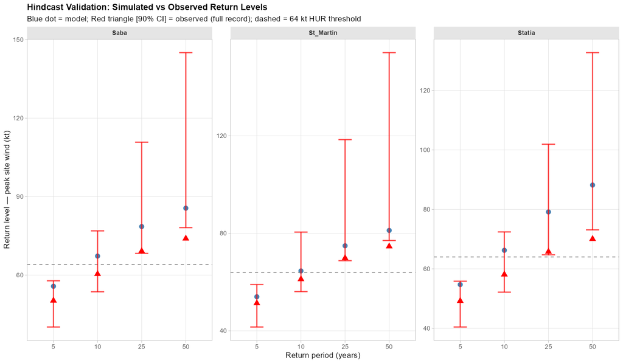

Figure 1: Hindcast validation: simulated vs observed return levels

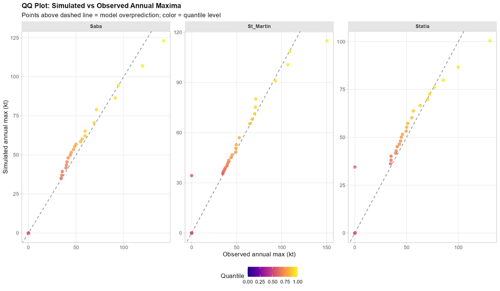

Figure 2: QQ plot of simulated versus observed annual maxima

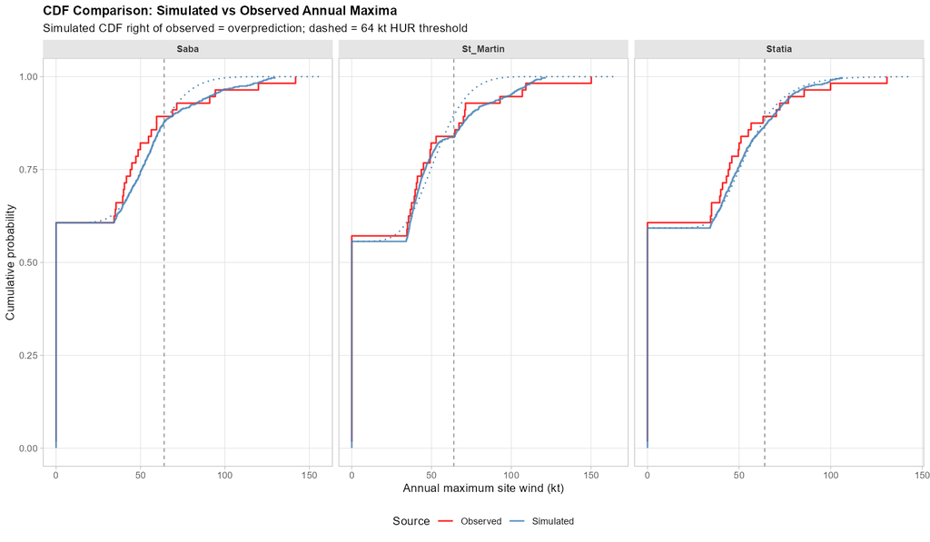

Figure 3: CDF comparison of simulated and observed annual maxima

**Why the CI is on the observed curve**

The confidence intervals are placed around the observed return levels, not the simulated ones. That is deliberate: uncertainty from the short observational record usually dominates over fitting uncertainty once you have a large synthetic sample.

**Start with the QQ plot**

The QQ plot is usually the fastest way to see whether the model is over- or under-predicting at different intensity levels. If the upper-tail points sit above the 1:1 line, the model is producing winds that are too strong in the tail.

## 8 Tier 2 — Rate Sanity Check

Tier 2 compares the model’s annual storm rates against published climatological rates from NHC/NOAA. This is a frequency check: are we getting the long-run number of tropical-storm and hurricane impacts at each site into the right range?

There is an important subtlety here. The model counts point exceedance at a target location, while reference climatologies often count storms whose centres pass within some radius of the site. The validation accounts for that mismatch through an expected ratio before applying its final flags.

```r
val$rate_check
```

```
#> # A tibble: 6 × 19
#>   location  storm_class lambda_model lambda_model_raw n_years_model lambda_ref
#>   <chr>     <chr>              <dbl>            <dbl>         <int>      <dbl>
#> 1 St_Martin TS                 0.553            0.553            47       0.8
#> 2 Saba      TS                 0.511            0.511            47       1.45
#> 3 Statia    TS                 0.511            0.511            47       1.45
#> 4 St_Martin HUR                0.191            0.191            47       0.4
#> 5 Saba      HUR                0.128            0.128            47       0.55
#> 6 Statia    HUR                0.149            0.149            47       0.55
#> # ℹ 13 more variables: lambda_target <dbl>, lambda_scale <dbl>,
#> #   lambda_adj <dbl>, scale_status <chr>, scale_clamped <lgl>, source <chr>,
#> #   gate_approx_nm <dbl>, period <chr>, expected_ratio <dbl>, raw_ratio <dbl>,
#> #   ratio <dbl>, adj_ratio <dbl>, flag <chr>
```

| Column | Description |
| --- | --- |
| `lambda_model_raw` | Raw annual rate estimated by the model before any adjustment. |
| `lambda_ref` | Published reference annual rate for that site and storm class. |
| `lambda_adj` | Adjusted model rate used for the comparison. |
| `adj_ratio` | Adjusted model-to-reference ratio after accounting for the expected methodological mismatch. |
| `flag` | Interpretation flag for the comparison result. |

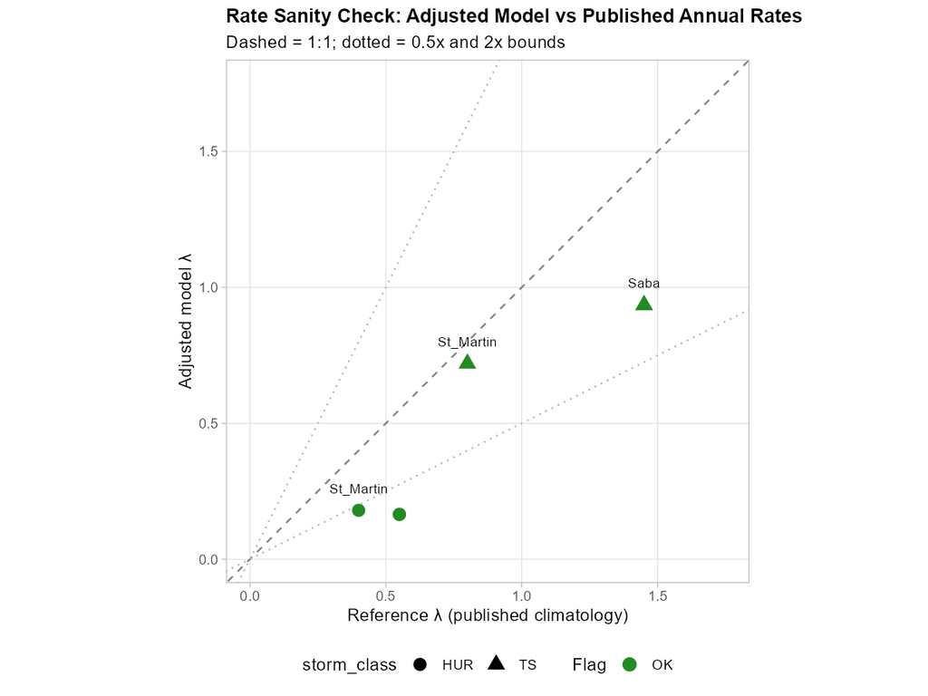

Figure 4: Rate sanity check: model versus published annual storm rates

**Rate-check flags**

`OK` means the adjusted ratio is within the expected range. `elevated` and `slightly_low` are mild discrepancies. `HIGH` and `LOW` indicate a stronger mismatch that deserves investigation.

## 9 Tier 3 — Wind Field Spot-Checks

Tier 3 compares modelled site winds for specific historical storms against observed station winds. This is the most direct physical check in the suite, because it asks whether the wind profile is producing plausible local winds for well-documented events.

The observations are grouped into quality classes. Class `A` is a direct station observation with a ±15% tolerance, `B` is a converted observation with a ±25% tolerance, and `C` is a more approximate estimate with a ±35% tolerance. That lets the validation use stricter expectations for higher-quality observations.

```r
val$wind_field
```

```
#> # A tibble: 8 × 19
#>   location    storm_name storm_sid  year station obs_raw_kt obs_type obs_quality
#>   <chr>       <chr>      <chr>     <int> <chr>        <dbl> <chr>    <chr>
#> 1 St_Martin   IRMA       2017242N…  2017 Meteo_…        113 10min_s… B
#> 2 St_Martin   GONZALO    2014279N…  2014 Julian…         60 1min_su… A
#> 3 Saba        IRMA       2017242N…  2017 NHC_es…         80 1min_su… C
#> 4 St_Martin   MARIA      2017255N…  2017 Julian…         40 1min_su… A
#> 5 Puerto_Rico HUGO       1989248N…  1989 Roosev…        104 1min_su… A
#> 6 Miami       ANDREW     1992216N…  1992 NHC_Mi…        141 1min_su… A
#> 7 St_Martin   LENNY      1999317N…  1999 Julian…         55 1min_su… A
#> 8 St_Martin   LUIS       1995241N…  1995 Julian…        110 1min_su… A
#> # ℹ 11 more variables: obs_1min_equiv_kt <dbl>, model_V_site_kt <dbl>,
#> #   model_wind_max_kt <dbl>, min_dist_km <dbl>, storm_found <lgl>,
#> #   bias_kt <dbl>, bias_pct <dbl>, bias_threshold_pct <dbl>, bias_ok <lgl>,
#> #   source <chr>, notes <chr>
```

| Column | Description |
| --- | --- |
| `storm_name` | Historical storm name used in the spot-check. |
| `location` | Target location for the comparison. |
| `obs_1min_equiv_kt` | Observed wind converted to a 1-minute sustained equivalent (kt). |
| `model_V_site_kt` | Modelled peak site wind (kt). |
| `bias_kt` | Model minus observed wind (kt). |
| `bias_pct` | Percentage bias. |
| `obs_quality` | Observation quality class (`A`, `B`, or `C`). |
| `bias_ok` | Whether the bias falls within the class-specific tolerance. |

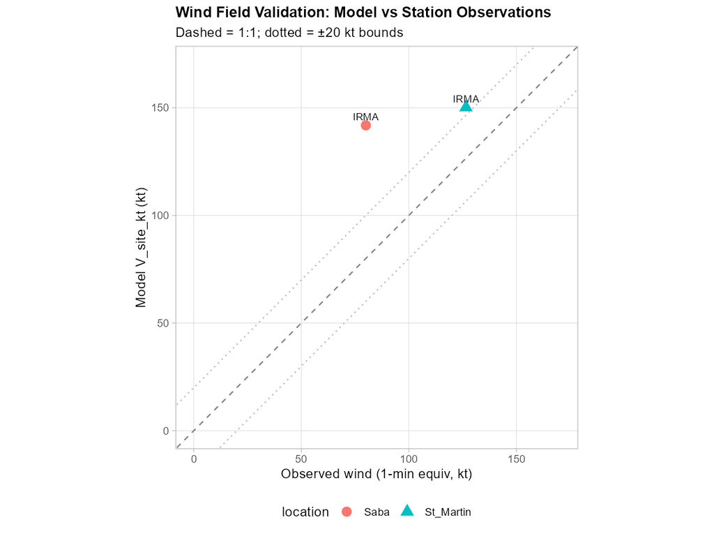

Figure 5: Wind field validation: modelled versus observed site winds

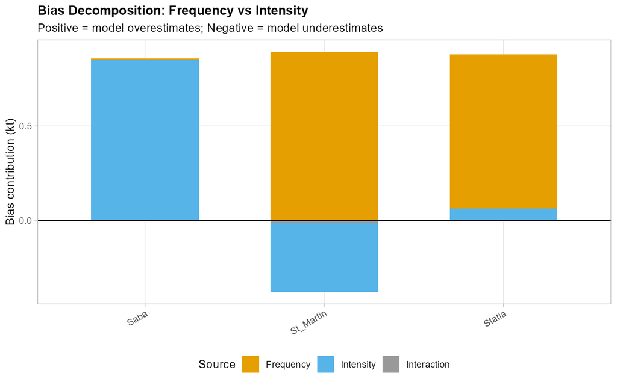

Figure 6: Bias decomposition into frequency and intensity contributions

**Wind field validation is the hardest tier**

Station observations are point measurements affected by terrain, exposure, and instrumentation. Biases of around ±20% are normal, so this tier is usually the hardest one to pass cleanly.

## 10 Interpreting Results and Next Steps

Start with the QQ plots and the bias decomposition. The QQ plots tell you where the model starts to drift away from the observed distribution, while the bias decomposition helps you separate a frequency problem from an intensity problem.

A frequency bias means the model is generating too many or too few storm impacts. That usually points you toward site filtering, event classification, or annual-rate calibration choices. An intensity bias means the storm counts may be reasonable, but the modelled site winds are too weak or too strong. That points more toward the wind-field parameterization and the way local wind magnitudes are being estimated.

If a tier fails, do not assume the whole model is unusable. The more useful question is which part of the workflow is being stressed by that failure, and whether the bias matters for your application.

**One-step shortcut**

If you already know the workflow and want a single entry point, `validate_hazard_model()` runs the hazard model and the validation suite in one call. It is convenient for repeat runs, but the two-step approach in this tutorial is easier to inspect and troubleshoot.

**Targeted reruns**

If you need to focus on one diagnostic only, the package also provides the individual tier functions `validate_hindcast()`, `validate_rates()`, and `validate_wind_field()`. This tutorial keeps the full suite as the main workflow so you can see the whole validation picture in one place.

## 11 Saved Outputs

When `save_plots = TRUE` and `save_tables = TRUE`, the validation suite writes a small report bundle to `output/validation/`. These files are useful if you want to share diagnostics, archive a run, or compare results across model versions.

| File | Description |
| --- | --- |
| `hindcast_return_levels.png` | Return level comparison with confidence intervals. |
| `rate_comparison.png` | Model versus published annual rate scatter. |
| `wind_field_scatter.png` | Model versus observed wind scatter. |
| `bias_decomposition.png` | Frequency versus intensity bias contributions. |
| `qq_annual_max.png` | QQ plot of annual maxima. |
| `exceedance_comparison.png` | CDF comparison of observed and simulated annual maxima. |
| `hindcast_return_levels.csv` | Hindcast comparison table. |
| `rate_check.csv` | Rate sanity check results. |
| `wind_field.csv` | Wind field spot-check results. |
| `validation_summary.csv` | Compact per-location validation summary. |

This validation workflow gives you a defensible baseline check before moving on to climate sensitivity, scenario analysis, or downstream impact modelling. Once you are comfortable reading the tier outputs, you can use the same pattern on your own sites and longer model runs.